# Assessing bicep curls

T Gocheco

January 25, 2016

## Overview

This study takes in the Weight Lifting Exercise Dataset from http://groupware.les.inf.puc-rio.br/har and generates an analytics model that predicts whether a dumbbell lift has been done correctly or not given different measurements taken from some fitness measurement devices. Data has been downloaded from below links:  
- https://d396qusza40orc.cloudfront.net/predmachlearn/pml-training.csv  
- https://d396qusza40orc.cloudfront.net/predmachlearn/pml-testing.csv

In this study, the pml-training.csv data will be split into a training and a test set, and the training set will be used to develop a prediction model, and then tested on the test set. Finally once the results are satisfactory, the model will be used to predict the 20 observations of data from the pml-testing.csv file, and properly classify whether the bicep curls were done correctly (classe A), or incorrectly as classified by classe B, C, D or E.

## Data Loading.

Loading training and testing data from files already downloaded. During loading, NA and blank fields are read as NA.

```r
pmltraining <- read.csv("./pml-training.csv", na.strings=c("NA", "#DIV/0!", ""));
pmltesting<- read.csv("./pml-testing.csv", na.strings=c("NA", "#DIV/0!", ""))
```

## Exploratory Data Analysis

Exploration done by doing a summary of the dataset. Around 100 variables have mostly NAs as values. See Appendix section, figure 1 for the summary.

## Data processing and cleaning.

Initial exploration shows 100 variables with mostly NA values. Following steps taken to identify the variables with NA, and removing them from the training and testing dataset.  
Also removing the first 7 columns which will not be considered as predictors in this study. These are timestamps and identifiers as to who was the subject, hence isn’t really a predictor.

```r
library(caret)
b <-as.data.frame(summary(pmltraining))
NAlist <- b[grep('*NA*', b$Freq),]$Var2
NAlist<- sub("^\\s+", "", NAlist)

pmltrainingsubset <- pmltraining[,-which(names(pmltraining) %in% NAlist)]
pmltestingsubset <- pmltesting[,-which(names(pmltraining) %in% NAlist)]
pmltrainingsubset <- pmltrainingsubset[,-c(1:7)]
pmltestingsubset <- pmltestingsubset[,-c(1:7)]
```

## Prepare cross-validation data.

Partition the original training data into 70% training and 30% test.

```r
set.seed(507)

inTrain<- createDataPartition(y=pmltrainingsubset$classe, p=0.7, list=FALSE)
training <- pmltrainingsubset[inTrain, ];
testing <- pmltrainingsubset[-inTrain,]
```

## Random forest Model creation.

Chosen model is random forest. Though random forest already has some built-in cross-validation given the nature of the algorithm, this study will still do a further test on the test set once a model is created with the training set.

Train the rainforest model with the training dataset with 53 variables, using default parameters of train.

```r
rffit <- train(classe ~ . , data=training, method="rf")
```

## Reviewing the result model.

Viewing the resulting rain forest model:

```r
rffit$finalModel
```

```
##
## Call:
##  randomForest(x = x, y = y, mtry = param$mtry)
##                Type of random forest: classification
##                      Number of trees: 500
## No. of variables tried at each split: 27
##
##         OOB estimate of  error rate: 0.68%
## Confusion matrix:
##      A    B    C    D    E class.error
## A 3900    4    1    0    1 0.001536098
## B   18 2632    8    0    0 0.009781791
## C    0   10 2375   11    0 0.008764608
## D    1    0   26 2221    4 0.013765542
## E    0    0    4    5 2516 0.003564356
```

The out of sample error is estimated to be only **0.68%** from the rainforest model. The confusion matrix returned by the best fit model seems to suggest an accuracy of **>98%** across all 5 classes.

Now let’s view the variable importance plot. The variable importance plot below shows that rollbelt, pitchforearm, and yawbelt variables have the most influence as predictors in our model.

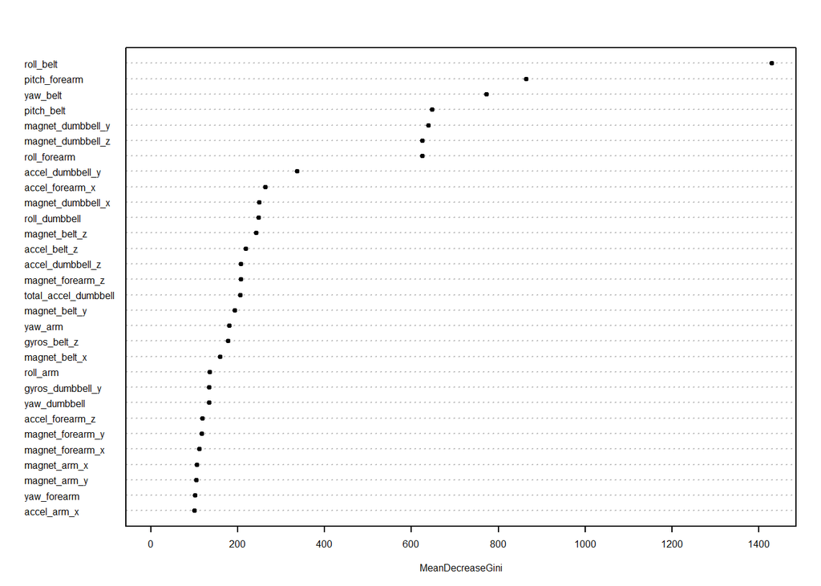

```r
varImpPlot(rffit$finalModel, type=2, pch=19, col=1, cex=.5, main="")
```

## Cross Validation of model using the 30% testing dataset.

We can now try the model on our test dataset as cross validation to check if the rainforest model performs as well with the testing dataset.

```r
testprediction <- predict (rffit, testing)

confusionMatrix(testprediction, testing$classe)$table
```

```
##           Reference
## Prediction    A    B    C    D    E
##          A 1672   15    0    0    0
##          B    1 1119   11    0    1
##          C    1    4 1010   11    3
##          D    0    1    5  953    1
##          E    0    0    0    0 1077
```

Confusion matrix for test set vs model prediction shows good prediction across all 5 classes as well.  
Accuracy of the fit with the test set shows 99.08%, or an error of 0.92%.

```r
confusionMatrix(testprediction, testing$classe)$overall
```

```
##       Accuracy          Kappa  AccuracyLower  AccuracyUpper   AccuracyNull
##      0.9908241      0.9883905      0.9880442      0.9930995      0.2844520
## AccuracyPValue  McnemarPValue
##      0.0000000            NaN
```

## Prediction of final test dataset

Predicting the 20 test data of the pmltesting data using the rainforest model.

```r
pmltestingpred <- predict(rffit, pmltestingsubset[,-53])
print(pmltestingpred)
```

```
##  [1] B A B A A E D B A A B C B A E E A B B B
## Levels: A B C D E
```

Inputting the results into the final prediction quiz shows that all 20 exercises were successfully predicted by the model.

## Appendix

### Figure 1: Summary of training dataset showing NA values.

```r
summary(pmltraining)
```

```
##        X            user_name    raw_timestamp_part_1 raw_timestamp_part_2
##  Min.   :    1   adelmo  :3892   Min.   :1.322e+09    Min.   :   294
##  1st Qu.: 4906   carlitos:3112   1st Qu.:1.323e+09    1st Qu.:252912
##  Median : 9812   charles :3536   Median :1.323e+09    Median :496380
##  Mean   : 9812   eurico  :3070   Mean   :1.323e+09    Mean   :500656
##  3rd Qu.:14717   jeremy  :3402   3rd Qu.:1.323e+09    3rd Qu.:751891
##  Max.   :19622   pedro   :2610   Max.   :1.323e+09    Max.   :998801
##
##           cvtd_timestamp  new_window    num_window      roll_belt
##  28/11/2011 14:14: 1498   no :19216   Min.   :  1.0   Min.   :-28.90
##  5/12/2011 11:24 : 1497   yes:  406   1st Qu.:222.0   1st Qu.:  1.10
##  30/11/2011 17:11: 1440               Median :424.0   Median :113.00
##  5/12/2011 11:25 : 1425               Mean   :430.6   Mean   : 64.41
##  2/12/2011 14:57 : 1380               3rd Qu.:644.0   3rd Qu.:123.00
##  2/12/2011 13:34 : 1375               Max.   :864.0   Max.   :162.00
##  (Other)         :11007
##    pitch_belt          yaw_belt       total_accel_belt kurtosis_roll_belt
##  Min.   :-55.8000   Min.   :-180.00   Min.   : 0.00    Min.   :-2.121
##  1st Qu.:  1.7600   1st Qu.: -88.30   1st Qu.: 3.00    1st Qu.:-1.329
##  Median :  5.2800   Median : -13.00   Median :17.00    Median :-0.899
##  Mean   :  0.3053   Mean   : -11.21   Mean   :11.31    Mean   :-0.220
##  3rd Qu.: 14.9000   3rd Qu.:  12.90   3rd Qu.:18.00    3rd Qu.:-0.219
##  Max.   : 60.3000   Max.   : 179.00   Max.   :29.00    Max.   :33.000
##                                                        NA's   :19226
##  kurtosis_picth_belt kurtosis_yaw_belt skewness_roll_belt
##  Min.   :-2.190      Mode:logical      Min.   :-5.745
##  1st Qu.:-1.107      NA's:19622        1st Qu.:-0.444
##  Median :-0.151                        Median : 0.000
##  Mean   : 4.334                        Mean   :-0.026
##  3rd Qu.: 3.178                        3rd Qu.: 0.417
##  Max.   :58.000                        Max.   : 3.595
##  NA's   :19248                         NA's   :19225
##  skewness_roll_belt.1 skewness_yaw_belt max_roll_belt     max_picth_belt
##  Min.   :-7.616       Mode:logical      Min.   :-94.300   Min.   : 3.00
##  1st Qu.:-1.114       NA's:19622        1st Qu.:-88.000   1st Qu.: 5.00
##  Median :-0.068                         Median : -5.100   Median :18.00
##  Mean   :-0.296                         Mean   : -6.667   Mean   :12.92
##  3rd Qu.: 0.661                         3rd Qu.: 18.500   3rd Qu.:19.00
##  Max.   : 7.348                         Max.   :180.000   Max.   :30.00
##  NA's   :19248                          NA's   :19216     NA's   :19216
```

[output cut: 313 more lines]

```
##  Min.   :-446.00   Min.   :-1280.0   Min.   :-896.0   Min.   :-973.0
##  1st Qu.:-182.00   1st Qu.: -616.0   1st Qu.:   2.0   1st Qu.: 191.0
##  Median : -39.00   Median : -378.0   Median : 591.0   Median : 511.0
##  Mean   : -55.29   Mean   : -312.6   Mean   : 380.1   Mean   : 393.6
##  3rd Qu.:  26.00   3rd Qu.:  -73.0   3rd Qu.: 737.0   3rd Qu.: 653.0
##  Max.   : 291.00   Max.   :  672.0   Max.   :1480.0   Max.   :1090.0
##
##  classe
##  A:5580
##  B:3797
##  C:3422
##  D:3216
##  E:3607
##
##
```

### Credits.

Velloso, E.; Bulling, A.; Gellersen, H.; Ugulino, W.; Fuks, H. Qualitative Activity Recognition of Weight Lifting Exercises. Proceedings of 4th International Conference in Cooperation with SIGCHI (Augmented Human ’13) . Stuttgart, Germany: ACM SIGCHI, 2013.

Read more: http://groupware.les.inf.puc-rio.br/har#ixzz3yGi7o6vv